# cow

**Correlates of War - Dataset Exploration**

**Course title: DSC 240 - Lab 02**

Liangze "Robert" Ke

*What is COW?*  
The Correlates of War (COW) project aims to **enhance the accessibility and reliability of quantitative data in the field of international relations**. The project is committed to **non-profit** sharing data sets with the research community, providing timely data releases, versioning for tracking, comprehensive dataset documentation, and continuous efforts to update and distribute improved dataset versions. The project utilizes its website as a central platform for data distribution, error reporting, user interaction, and community engagement to advance the project's development **within the realm of international relations**.

*Who are in charge of the datasets?*  
According to COW websites, **Associate Directors (Bennett)** is in charge of supervising and managing the datasets. **Advisory Boards (D'Orazio *et al*)** is in charge of designing, structring, and encoding of datasets. Finally, **the Data Hosts (Gibler *et al*)**: who are in charge of their hosting dataset (one by each person) and maintains the correctness and completeness of such.

Commercial or profit-driven usage of the site is **forbidden**.  
**_Who are the people and institutions involoved?_**  
Apart from the people mentioned above, there are other important people and instituions worth mentioning. The **COW data archive** is currently at the dispose of Bennett at **Pennsylvania State University**. Twice a year **COW meetings** are hosted on behalf of **International Studies Association and Peace Science Society (International)** respectively. **Data preserving** is "decenturalized", they are taken care by **(Gibler _et al_) University of Alabama, University of North Texas, etc**. Also, COW is **externally linked and exchanging thoughts and data** with respected institutions including **American Political Science Association, European Political Science Association**, etc.

*Below is a spreadsheet about the datasets and its relevant info.*

| Data | People in Charge | Organization | Time Period | Content |
| --- | --- | --- | --- | --- |
| State System Membership | COW Project Team | Correlates of War | Since 1816 | Records changes in the composition of the state system and corresponding country codes. |
| COW War Data | COW Project Team | Correlates of War | 1816-2007 | Lists wars categorized into non-state, intra-state, inter-state, and extra-state conflicts. |
| Militarized Interstate Disputes | COW Project Team | Correlates of War | 1816-2014 | Records instances of states threatening, displaying, or using force against each other. |
| National Material Capabilities | COW Project Team | Correlates of War | Various | Includes indicators like military expenditure, personnel, energy consumption, etc., for states. |
| Militarized Interstate Dispute Locations | COW Project Team | Correlates of War | 1816-2010 | Records geographic locations (latitude/longitude) of militarized interstate disputes. |
| World Religion Data | Zeev Maoz, Errol A. Henderson | Various | 1945-2010 | Provides religious adherence information worldwide from 1945 to 2010. |
| Formal Alliances | Douglas Gibler | University of Alabama | 1816-2012 | Records formal alliances among states, including defense pacts and non-aggression treaties. |
| Direct Contiguity | Paul Hensel | University of North Texas | 1816-2016 | Identifies land and sea borders between states since the Congress of Vienna. |
| Territorial Change | Steven V. Miller | Clemson University | 1816-2018 | Records peaceful and violent changes of territory involving nation-states. |
| Colonial/Dependency Contiguity | Correlates of War Team | Correlates of War | 1816-2016 | Registers contiguity relationships between colonies/dependencies of states, by land and sea. |
| Intergovernmental Organizations | Timothy Nordstrom | University of Mississippi | 1815-2014 | Tracks the status and membership of intergovernmental organizations. |
| Defense Cooperation Agreement | Brandon Kinne | University of California, Davis | 1980-2010 | Covers bilateral defense treaties between countries from 1980 to 2010. |
| Diplomatic Exchange | Reşat Bayer | Koç University | 1817-2005 | Tracks diplomatic representation levels (chargé d’affaires, minister, ambassador) between states. |
| Trade | Katherine Barbieri | University of South Carolina | 1870-2014 | Monitors total national and bilateral trade flows between states from 1870 to 2014. |

NMC v5 is *NOT* the latest version. NMC v6 is the latest.

**_What has been updated?_**  
**I. Military data update:** In 2017, updates to MILPER data (Military Personnel) were implemented for NMC v5.0, enhancing accuracy and detail, particularly for the 2002-2007 and 2008-2012 periods. These revisions included recalculating specific MILPER values and improving source information, providing a more refined and informative dataset compared to the previous NMC v4.0 from 2010.  
**II.Population data update:** The 2017 update of total population data followed the methodology from the 2010 (4.0) update, involving a comprehensive revision of total population figures for the 2002-2007 period and an extension for 2008-2012 to enhance data consistency. The update primarily sourced data from the online version of the UN World Urbanization Prospects, 2014 Revision, with exceptions for Kosovo and Taiwan where data was derived from the World Bank and National Statistics Republic of China Social Indicators reports, respectively, ensuring accurate and consistent data without requiring interpolation or extrapolation for the 2002-2012 period.  
**III. Steel update:**The World Steel Association’s Steel Statistical Yearbook 2013 (Table 1, “Total Production of Crude Steel”) was employed to update IRST for the period 2008-2012.  
**IV. Population updates:** Starting in 2002, a transition in how urban population data is generated was initiated, aiming to shift from urban population to urban agglomeration as a measure. The 2017 update significantly improved access to comprehensive urban agglomeration data, addressing limitations in the previous UN Demographic Yearbook source. Also, political regions like Taiwan, Kesovo were reclassfied.  
**There are also other updates on variety of details, mainly, more up-to-date, more accurate, more complete compared to v4.**

**Codebook, variables summary:**

| Position | Variable | Description |
| --- | --- | --- |
| 1 | stateabb | 3 letter country Abbreviation |
| 2 | ccode | COW Country code |
| 3 | year | Year of observation |
| 4 | milex | Military Expenditures (For 1816-1913: thousands of current year British Pounds. For 1914+: thousands of current year US Dollars.) |
| 5 | milper | Military Personnel (thousands) |
| 6 | irst | Iron and steel production (thousands of tons) |
| 7 | pec | Primary energy consumption (thousands of coal-ton equivalents) |
| 8 | tpop | Total Population (thousands) |
| 9 | upop | Urban population (In thousands. For 1816-2001: population in cities w/>=100k; For 2002-2012: population in cities w/>=300k) |
| 10 | cinc | Composite Index of National Capability (CINC) score |
| 11 | version | Version number of the data set |

| Name | Description |
| --- | --- |
| statenme | State name |
| stateabb | 3 letter country Abbreviation |
| ccode | COW Country code |
| year | Year of observation |
| milex | Military Expenditures |
| milexsource | Source – military expenditures |
| milexnote | Notes – military expenditures |
| milper | Military Personnel |
| milpersource | Source – military personnel |
| milpernote | Notes – military personnel |
| irst | Iron/Steel Production |
| irstsource | Source – Iron/Steel |
| irstnote | Notes – Iron/Steel |
| irstqualitycode | Quality Code – Iron/Steel |
| irstanomalycode | Anomaly Code – Iron/Steel |
| pec | Energy Consumption |
| pecsource | Source – energy consumption |
| pecnote | Notes – energy consumption |
| pecqualitycode | Quality Code – energy consumption |
| pecanomalycode | Anomaly Code – energy consumption |
| tpop | Total Population |
| tpopsource | Source – total population |
| tpopnote | Notes – total population |
| tpopqualitycode | Quality Code – total population |
| tpopanomalycode | Anomaly Code – total population |
| upop | Urban Population |
| upopsource | Source – urban population |
| upopnote | Notes – urban population |
| upopqualitycode | Quality Code – urban population |
| upopanomalycode | Anomaly Code – urban population |
| upopgrowth | Growth rate – urban population |
| upopgrowthsource | Growth rate source – urban population |
| cinc | Composite Index of National Capability (CINC) score |
| version | Version number of the data set |

Here are the major source institutions and articles mentioned in the provided text:  
**1. Australia’s HDR Resources:**  
Description: The University of New South Wales School of Petroleum Engineering Website.  
**2. CIA World Factbook (2002):**  
Description: Published by the Central Intelligence Agency.  
**3. Darmstadter, Joel, Perry D. Teiterbaum and Jaroslav G. Polach. (1971). Energy in the World Economy: A Statistical Review of Trends in Output, Trade, and Consumption Since 1925.:**  
Description: Statistical review of energy trends.  
**4. Source: Washington, DC: Johns Hopkins Press. Energy Statistics Yearbook (United Nations. Statistical Office) (1997):**  
Description: Provides conversion formulas and data on energy consumption.  
**5. Source: New York: United Nations Press.**  
Description: Electronic version transmitted via CD-ROM, providing energy consumption data.  
**6. Mitchell, B.R. (1998). International Historical Statistics: The Americas 1750-1993. Fourth Edition.:**  
Description: Contains international historical statistics on most states from 1816 until approximately 1993, including energy commodity data. Source: New York, New York: Stockton Press.

**Identification problems**  
**1. Definition and Operationalization of Variables:** Many political, military concepts are hard to quantify. The paper use *proxy variable* for politcal, religous, and military status for a country. This may cause a *operationalization error*, that is, there is a difference between proxies and reality.  
**2. Missing Data:** The data encoded -9 is missing, which may cause information incompleteness.  
**3. Aggregation Level Mismatch (improper integration):** Aggregating data at different levels (e.g., country-level, regional-level) may obscure important variations and nuances, affecting causal inference. Also, some regions with geo-political controversies may have caveats with data.  
**4. Heterogeneity of Units:** Units (e.g., countries) may vary significantly in terms of size, population, geopolitical influence, etc., making it challenging to treat them uniformly in causal analysis.

```python
import pandas as pd
import matplotlib.pyplot as plt
import seaborn as sns

filepath = "NMC_5_0.csv"
NMC_df = pd.read_csv(filepath)
```

**Codebook: NMC 5.0: -9 is the encoding for missing values**

```
top10 country:
_______________________
13141    CHN
196      USA
13658    IND
7863     RUS
13592    JPN
2929     BRA
13445    ROK
5572     GMY
11720    IRN
3930     UKG
Name: stateabb, dtype: object
_______________________
```

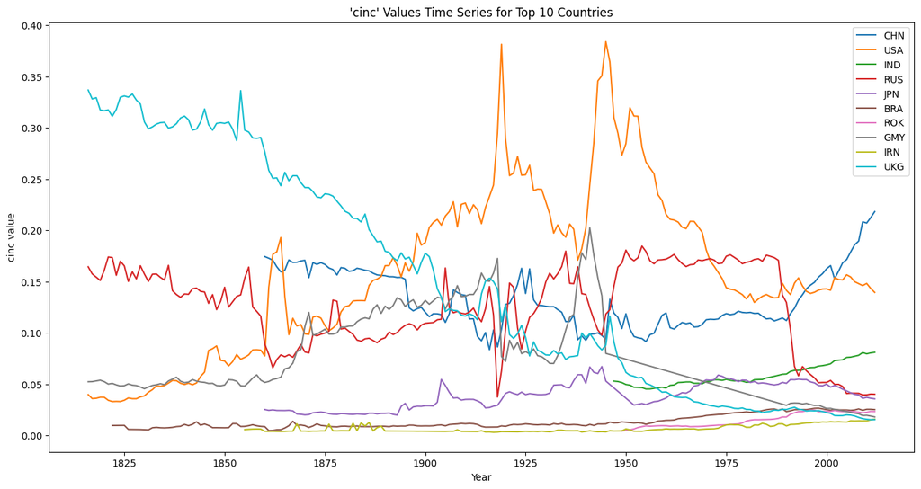

```python
#Remove the missing observations indicated with ‘-9’
NMC_df.replace('-9',pd.NA,inplace=True)
NMC_df.dropna(inplace=True)

top10_country = NMC_df[NMC_df['year']==2012].sort_values(by='cinc', ascending=False)[0:10].stateabb
print('top10 country:')
print('_______________________')
print(top10_country)
print('_______________________')
top10_data = NMC_df[NMC_df['stateabb'].isin(top10_country)]
#print(top10_data)
plt.figure(figsize=(16,8))
for country in top10_country:
    data = top10_data[top10_data['stateabb']== country]
    x = data['year']
    y = data['cinc']
    plt.plot(x,y,label=country)
plt.xlabel('Year')
plt.ylabel('cinc value')
plt.title("'cinc' Values Time Series for Top 10 Countries")
plt.legend()
plt.show()
```

*Observation*  
The above time series show: *the countries with relative high cinc value, the time series are non-stationary.* Those with relatively low cinc value has stationary time series. This makes sense since large economy has a more complicated political and demographic system, which brings uncertainties and random noises to the time series.

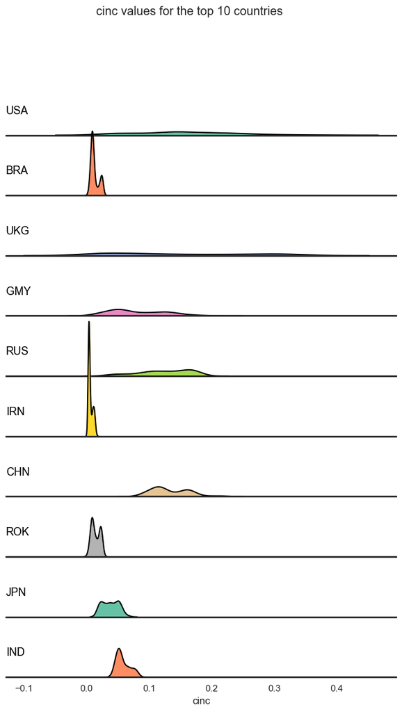

```python
sns.set_theme(style="white", rc={"axes.facecolor": (0, 0, 0, 0), 'axes.linewidth':2})
palette = sns.color_palette("Set2", 12)
g = sns.FacetGrid(top10_data, palette=palette, row='stateabb',hue='stateabb', aspect=6, height=1.2)
g.map_dataframe(sns.kdeplot, x="cinc",fill=True, alpha=1)
g.map_dataframe(sns.kdeplot, x="cinc", color='black')
def label(x, color, label):
    ax = plt.gca()
    ax.text(0, .2, label, color='black', fontsize=13,
            ha="left", va="center", transform=ax.transAxes)
g.map(label, "stateabb")
g.fig.subplots_adjust(hspace=-.5)
g.set_titles("")
g.set(yticks=[],xlabel="cinc")
g.set_ylabels("")
g.despine(left=True)
plt.suptitle('cinc values for the top 10 countries', y=0.98)
```

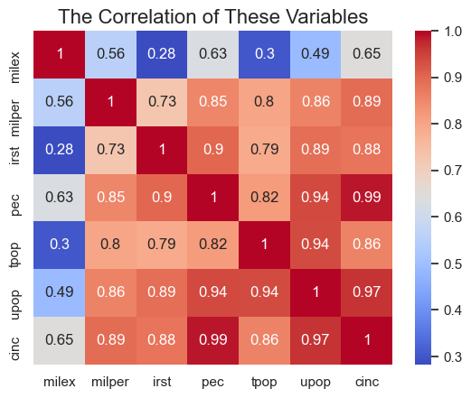

```python
#Extract the observation from the year 2012 for each country in the dataset and discard all of the other observations
df_2012 = NMC_df[NMC_df['year']==2012]
#print(df_2012)
#Calculate the correlations between milex, milper, irst, pec, tpop, upop, cinc
df_2012_corr=df_2012[['milex', 'milper', 'irst', 'pec', 'tpop', 'upop', 'cinc']].corr()
#print('the correlation of these variables:')
#print(df_2012_corr)
#create a heatmap
plt.title('The Correlation of These Variables', fontsize=16)
sns.heatmap(df_2012_corr, annot=True,cmap='coolwarm')
plt.show()
```

*Variables correlated by nature*?  
**1. Tpop (Total Population) and Upop (Urban Population):**  
It's likely that total population (tpop) and urban population (upop) are correlated. As a country's overall population increases, its urban population is likely to increase proportionally due to factors such as urbanization and migration to cities.  
**2. Tpop (Total Population) and Pec (Primary Energy Consumption):**  
Total population (tpop) and primary energy consumption (pec) may be correlated. Larger populations generally require more energy for various purposes, including household and industrial needs.  
**3. Upop (Urban Population) and Pec (Primary Energy Consumption):**  
Urban population (upop) and primary energy consumption (pec) might be correlated as well. Urban areas tend to have higher energy needs due to concentrated economic activities, transportation systems, and residential consumption.  
**4. Milex (Military Expenditures) and Milper (Military Personnel):**  
Military Expenditures and personnel has simultaniety relationship. As more military personnel requires more budget to train, accomodate, and administrate. Also, more military expenditures spent on facilities and crafts require expertise personnel to take care.

*Positive correlated features? Negative? Impact on outcomes?*  
Positive correlated:  
**1. Overfitting:** Including too many correlated variables may lead to overfitting, where the model mitigates the noise in the data rather than finding true underlying relationships between outcomes and features.  
**2. Multicollinearity:** Including highly correlated variables can introduce multicollinearity. This can make it difficult to separate the individual effect of each variable on the outcome. Multicollinearity violates the assumption of the independence property of the variables.  
Negative correlated:  
**1. Inverse Impact on the Outcome:** An increase in one variable is associated with a decrease in the other. Consequently, the outcome variable is likely to be affected in the opposite direction.  
**2. Offset the multicollinearity:** If two variables are highly negatively correlated, including both in the model (acting like a proxy variable for the positive multicolinearity) might stabilize the model and improve the estimation of the individual effects of each variable.

```python
from sklearn.preprocessing import minmax_scale
from scipy.spatial.distance import euclidean, cityblock
import operator

#Standardize the variables between 0 and 1
#only use the columns in correlation
df_2012_use = df_2012[['milex', 'milper', 'irst', 'pec', 'tpop', 'upop', 'cinc']]
#this is a array, each element is the stardardized variables for a country
df_2012_scaled = minmax_scale(df_2012_use, feature_range=(0, 1), axis=0, copy=True)

#Calculate the pairwise Euclidean distances between countries, put it in a dictionary
country_Eucdis={}
for i in range(len(df_2012_scaled)):
    for j in range(i+1, len(df_2012_scaled)):
           country_Eucdis[i,j] = euclidean(df_2012_scaled[i], df_2012_scaled[j])
#sort the values of country_Eucdis dictionary from smallest to largest
sort_country_Eucdis = sorted(country_Eucdis.items(),key=operator.itemgetter(1))
#Find the top 10 smallest Euclidean distance country pairs
small_Euc=[]
for x in list(sort_country_Eucdis)[0:10]:
    #print(x)
    small_Euc.append(x[0])
print('here are the 10 country pairs having smallest Euclidean distance in ascending order:')
for y in small_Euc:
    print(df_2012.iloc[y[0]]['stateabb'],"and", df_2012.iloc[y[1]]['stateabb'])
```

```
here are the 10 country pairs having smallest Euclidean distance in ascending order:
TUV and NAU
SKN and MSI
KIR and TON
MNC and LIE
GRN and SVG
SVG and TON
LIE and SNM
GRN and TON
MNC and SNM
SLU and WSM
```

```python
#Calculate the pairwise Manhattan distances between countries, put it in a dictionary
country_Mandis={}
for i in range(len(df_2012_scaled)):
    for j in range(i+1, len(df_2012_scaled)):
           country_Mandis[i,j] = cityblock(df_2012_scaled[i], df_2012_scaled[j])
#sort the values of country_Mandis dictionary from smallest to largest
sort_country_Mandis = sorted(country_Mandis.items(),key=operator.itemgetter(1))
#Find the top 10 smallest Manhattan distance country pairs
small_Man=[]
for x in list(sort_country_Mandis)[0:10]:
    #print(x)
    small_Man.append(x[0])
print('here are the 10 country pairs having smallest Manhattan distance in ascending order:')
for y in small_Man:
    print(df_2012.iloc[y[0]]['stateabb'],"and", df_2012.iloc[y[1]]['stateabb'])
```

```
here are the 10 country pairs having smallest Manhattan distance in ascending order:
TUV and NAU
SKN and MSI
KIR and TON
MNC and LIE
GRN and SVG
GRN and TON
SVG and TON
MNC and SNM
LIE and SNM
SLU and WSM
```

```python
sub_df1 = df_2012[df_2012['stateabb'].isin(['TUV','NAU'])]
sub_df2 = df_2012[df_2012['stateabb'].isin(['LIE','MNC'])]
```

```python
sub_df1
```

|  | stateabb | ccode | year | milex | milper | irst | pec | tpop | upop | cinc | version |
| --- | --- | --- | --- | --- | --- | --- | --- | --- | --- | --- | --- |
| 14999 | TUV | 947 | 2012 | 0 | 0 | 0 | 1 | 10.0 | 0.0 | 2.440000e-07 | 2011 |
| 15070 | NAU | 970 | 2012 | 0 | 0 | 0 | 3 | 10.0 | 0.0 | 2.600000e-07 | 2011 |

Tuvalu and Nauru are both *small in terms of land area, population, and economy*. They face similar challenges related to climate change and their vulnerability to rising sea levels due to their low-lying coastal geography. Also, since they are both extremely limited in size, population, and resources, their value ended up as being extremely identical.

```python
sub_df2
```

|  | stateabb | ccode | year | milex | milper | irst | pec | tpop | upop | cinc | version |
| --- | --- | --- | --- | --- | --- | --- | --- | --- | --- | --- | --- |
| 4699 | MNC | 221 | 2012 | 0 | 0 | 0 | 138 | 38.0 | 0.0 | 0.000002 | 2011 |
| 4722 | LIE | 223 | 2012 | 0 | 0 | 0 | 154 | 37.0 | 0.0 | 0.000002 | 2011 |

Liechtenstein and Monaco share similarities in terms of their size, as *both are microstates with limited territory and a small population*. They have relatively **small militaries and defense budgets compared to larger nations**. Given their **geographic location in Europe** and their small size, they are not typically known for substantial military capabilities.

Since they encounter same demographic and regional traits, their numbers are likely to be identical.

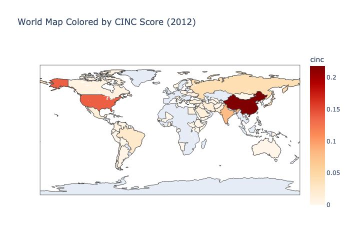

```python
import pandas as pd
import plotly.express as px
import plotly.io as pio

# Read data
filepath = "NMC_5_0.csv"
data = pd.read_csv(filepath)
data_2012 = data[data['year'] == 2012][['stateabb', 'cinc']]

# Create the figure
fig = px.choropleth(
    data_2012,
    locations="stateabb",
    color="cinc",
    hover_name="stateabb",
    color_continuous_scale=px.colors.sequential.OrRd,
    title="World Map Colored by CINC Score (2012)"
)

# Convert the figure to an image (PNG) and embed in the notebook
from IPython.display import Image
img_bytes = fig.to_image(format="png")
display(Image(img_bytes))
```

*When will the conflicts happen? Are they likely*?  
According to this graph and information provided, People Republic of China and Republic of Inida are two nations likely result in clash. There has been **small scale geopolitical conflicts on the borderlines and economic sanctions between two countries.** in the past decade, but nothing beyond that happened.  
*What are some potential deficiencies of the model?*  
I think one of the major omitted variable of conflict **is socio-political ideology**. Democracy or non-democracy. Right-wing radicalism or left-wing conservatism. Also historical conflicts. ex. North/South Korea.